# BA_Assignment2

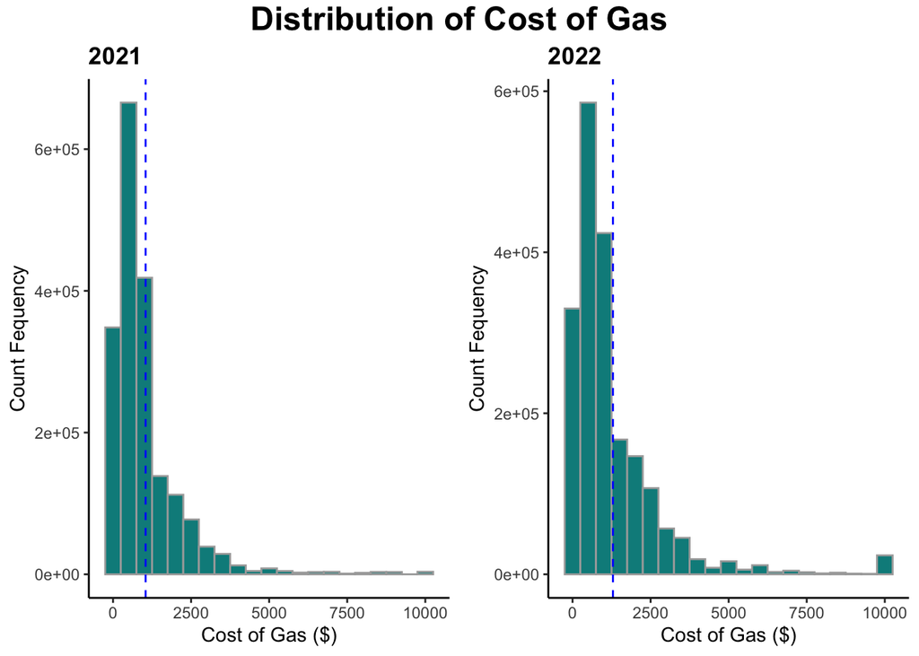

```r
hist_COSTGAS21 <- q2_data_gas %>%
                    filter(YEAR == 2021) %>%
                    ggplot(aes(x = COSTGAS)) +
                      geom_histogram(binwidth = 500L, fill = "darkcyan", color = "darkgrey") +
                      geom_vline(aes(xintercept = mean(COSTGAS)), color = "blue", linetype = "dashed") +
                      labs(title = "2021") +
                      xlab(label = "Cost of Gas ($)") +
                      ylab(label = "Count Fequency") +
                      theme_classic() +
                      theme(plot.title = element_text(face = "bold"),
                            legend.position = "none")

hist_COSTGAS22 <- q2_data_gas %>%
                    filter(YEAR == 2022) %>%
                    ggplot(aes(x = COSTGAS)) +
                      geom_histogram(binwidth = 500L, fill = "darkcyan", color = "darkgrey") +
                      geom_vline(aes(xintercept = mean(COSTGAS)), color = "blue", linetype = "dashed") +
                      labs(title = "2022") +
                      xlab(label = "Cost of Gas ($)") +
                      ylab(label = "Count Fequency") +
                      theme_classic() +
                      theme(plot.title = element_text(face = "bold"),
                            legend.position = "none")

hist_COSTGAS <- ggarrange(hist_COSTGAS21, hist_COSTGAS22,
                          ncol = 2, nrow = 1,
                          widths = c(1,1), heights = c(1,1))
hist_COSTGAS <- annotate_figure(hist_COSTGAS,
                                top = text_grob("Distribution of Cost of Gas",
                                                color = "black",
                                                face = "bold",
                                                size = 18))
hist_COSTGAS
```

```r
q2_water_2021 <- q2_data_water %>%
                   filter(YEAR == 2021) %>%
                   group_by(STATEFIP) %>%
                   summarise(maxCOSTWATR21 = max(COSTWATR)) %>%
                   slice_max(maxCOSTWATR21, n = 1)

q2_water_2022 <- q2_data_water %>%
                   filter(YEAR == 2022) %>%
                   group_by(STATEFIP) %>%
                   summarise(maxCOSTWATR22 = max(COSTWATR)) %>%
                   slice_max(maxCOSTWATR22, n = 1)

q2_water <- merge(q2_water_2021, q2_water_2022, all = TRUE)
q2_water
```

```
##   STATEFIP maxCOSTWATR21 maxCOSTWATR22
## 1        6          6200            NA
## 2       15            NA          7100
```

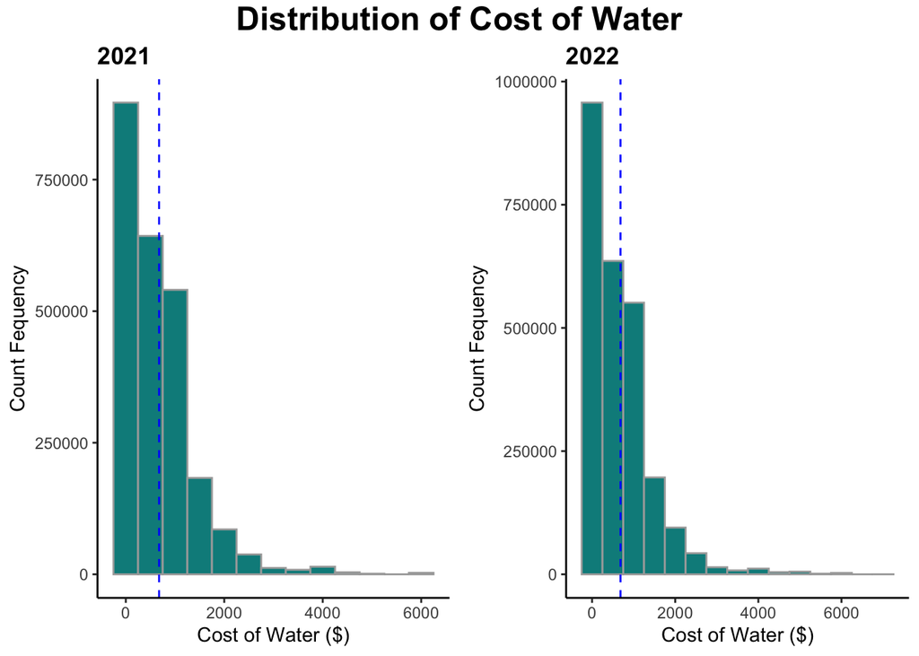

```r
hist_COSTWATR21 <- q2_data_water %>%
                     filter(YEAR == 2021) %>%
                     ggplot(aes(x = COSTWATR)) +
                       geom_histogram(binwidth = 500L, fill = "darkcyan", color = "darkgrey") +
                       geom_vline(aes(xintercept = mean(COSTWATR)), color = "blue", linetype = "dashed") +
                       labs(title = "2021") +
                       xlab(label = "Cost of Water ($)") +
                       ylab(label = "Count Fequency") +
                       theme_classic() +
                       theme(plot.title = element_text(face = "bold"),
                             legend.position = "none")

hist_COSTWATR22 <- q2_data_water %>%
                     filter(YEAR == 2022) %>%
                     ggplot(aes(x = COSTWATR)) +
                       geom_histogram(binwidth = 500L, fill = "darkcyan", color = "darkgrey") +
                       geom_vline(aes(xintercept = mean(COSTWATR)), color = "blue", linetype = "dashed") +
                       labs(title = "2022") +
                       xlab(label = "Cost of Water ($)") +
                       ylab(label = "Count Fequency") +
                       theme_classic() +
                       theme(plot.title = element_text(face = "bold"),
                             legend.position = "none")

hist_COSTWATR <- ggarrange(hist_COSTWATR21, hist_COSTWATR22,
                           ncol = 2, nrow = 1,
                           widths = c(1,1), heights = c(1,1))
hist_COSTWATR <- annotate_figure(hist_COSTWATR,
                          top = text_grob("Distribution of Cost of Water",
                                          color = "black",
                                          face = "bold",
                                          size = 18))
hist_COSTWATR
```

## 5.3 Question_3; Are there any states with an imbalance in Sex?

Answer_Q3; According to the sample, there are imbalance in Gender in every states. As the table below, the different clearly shown in every states. The highest different is 6.98% at The District of Columbia, in the other hand, the smallest different is 0.04% at The States of Utah.  
For a solid conclusion, I performed hypothesis testing as ‘H0; mean different between proportion of Male and Female = 0’. The p-value is 0.000001712 which is less than 0.05, so that, H0 is rejected and accept H1. There is the different between the proportion of Male and Female, the mean different is -1.53% which mean the proportion of Female is larger than Male.  
I also create a box plot of the proportion different in percentage between Male and Female. The mean and median is closed to each other at -1.53%. The distribution seems to be a normal bell curve, with few potential outliers in both tails. I created the z-score, and found that there is one outlier at the right tail. Alaska is an outlier which have Male 6% more than Female populations.

```r
# Data construction
q3_data <- maindf %>%
             select(STATEFIP, SEX) %>%
             filter(SEX != 9) %>%
             group_by(STATEFIP) %>%
             summarise(Male = COUNTIF(SEX, 1),
                       Female = COUNTIF(SEX, 2),
                       percMale = round(100 * (Male/(Male + Female)), digits = 2),
                       percFemale = round(100 * (Female/(Male + Female)), digits = 2),
                       percDiff = percMale - percFemale)
```

```r
# Hypothesis testing
## H0: Male - Female = 0
## H1: Male - Female <> 0
t.test(x = q3_data$percDiff, y = NULL, alternative = c("two.side"), mu = 0)
```

```
##
##  One Sample t-test
##
## data:  q3_data$percDiff
## t = -5.4209, df = 50, p-value = 1.712e-06
## alternative hypothesis: true mean is not equal to 0
## 95 percent confidence interval:
##  -2.0966293 -0.9629786
## sample estimates:
## mean of x
## -1.529804
```

```
## [1] "p-value = 0.000001712. Then At 95% Confidence Interval, HO is rejected as p-value < 0.05 and accept alternative hypothesis. The different between number of Male and Female is more than 0, so there is an imbalance in Sex"
```

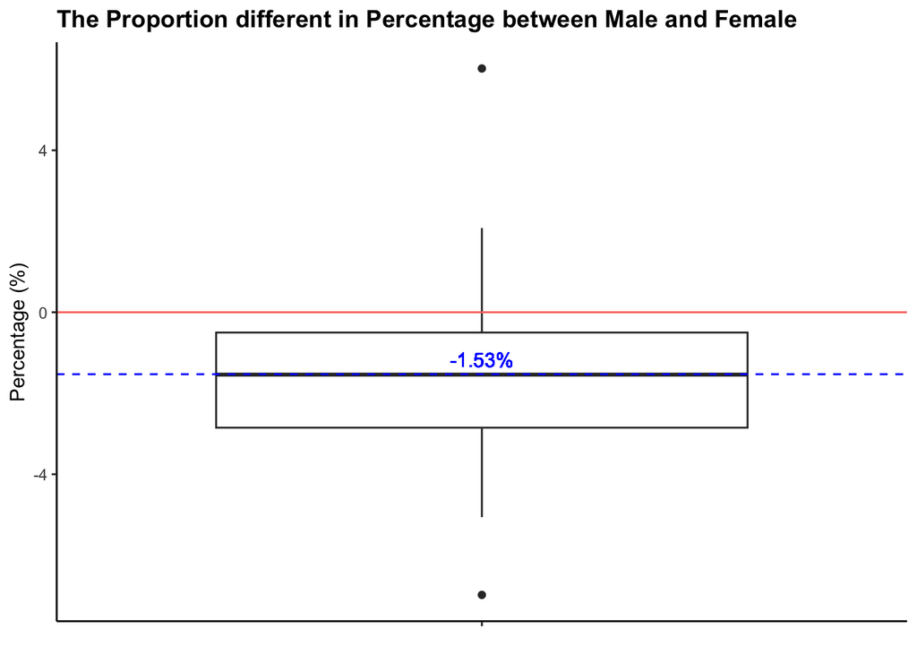

```r
# Create box plot the different between Male and Female proportion in percentage
q3_box <- q3_data %>%
            ggplot() +
              geom_boxplot(aes(x = "", y = percDiff)) +
              geom_hline(aes(yintercept = mean(percDiff)), color = "blue", linetype = "dashed") +
              geom_hline(aes(yintercept = 0, color = "red")) +
              geom_text(aes(x = "",
                            y = mean(percDiff),
                            label = paste(round(mean(percDiff), digits = 2), "%", sep = "")),
                        color = "blue",
                        vjust = -0.5) +
              labs(title = "The Proportion different in Percentage between Male and Female") +
              xlab(label = NULL) +
              ylab(label = "Percentage (%)") +
              theme_classic() +
              theme(plot.title = element_text(face = "bold"),
                    legend.position = "none")

q3_box
```

```r
ZpercDiff <- q3_data %>%
               mutate(zScore = (percDiff-mean(percDiff))/sqrt(var(percDiff)))
ZpercDiff
```

```
## # A tibble: 51 × 7
##    STATEFIP   Male Female percMale percFemale percDiff zScore
##    <fct>     <int>  <int>    <dbl>      <dbl>    <dbl>  <dbl>
##  1 1         48892  52335     48.3       51.7   -3.40  -0.928
##  2 2          7094   6289     53.0       47.0    6.02   3.75
##  3 4         72898  74280     49.5       50.5   -0.940  0.293
##  4 5         30006  31332     48.9       51.1   -2.16  -0.313
##  5 6        384142 393090     49.4       50.6   -1.16   0.183
##  6 8         59159  58813     50.2       49.8    0.300  0.908
##  7 9         35805  38229     48.4       51.6   -3.28  -0.868
##  8 10         9050  10015     47.5       52.5   -5.06  -1.75
##  9 11         6456   7424     46.5       53.5   -6.98  -2.70
## 10 12       204971 215711     48.7       51.3   -2.56  -0.511
## # ℹ 41 more rows
```

```r
ZpercDiff_outlier <- ZpercDiff %>%
                       filter(zScore < -3 | zScore > 3)
ZpercDiff_outlier
```

```
## # A tibble: 1 × 7
##   STATEFIP  Male Female percMale percFemale percDiff zScore
##   <fct>    <int>  <int>    <dbl>      <dbl>    <dbl>  <dbl>
## 1 2         7094   6289     53.0       47.0     6.02   3.75
```

## 5.4 Question_4; Create a new variable that indicates the Total Annual cost that is the sum of the cost of Electricity, Gas, and Water. Which states have the highest total cost?

Answer_Q4; The highest total cost of Electric, Gas, and Water is The State of California (FIP Code = 6), for both 2021 and 2022. I started with filter out unusable rows, according to the code book. Since I curious about the number of observations of each States which is directly effect the calculation. I found that number of observations of The State of California is the highest in every variables, that’s strongly support the findings. I also found that The State of California have the highest total cost of each category in both 2021 and 2022.

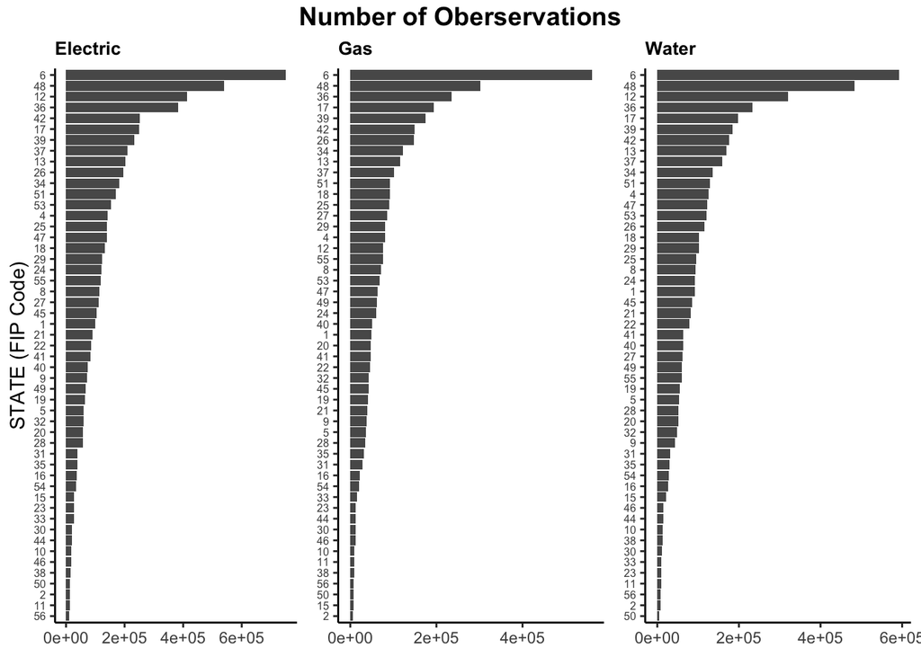

```r
## Subsetting data
q4_data_electric <- maindf %>%
                      select(STATEFIP, YEAR, COSTELEC) %>%
                      filter(COSTELEC < 9993)

q4_data_gas <- maindf %>%
                 select(STATEFIP, YEAR, COSTGAS) %>%
                 filter(COSTGAS < 9992)

q4_data_water <- maindf %>%
                   select(STATEFIP, YEAR, COSTWATR) %>%
                   filter(COSTWATR < 9993)

## Want to know how many observations of each STATES
q4_obs_elec <- q4_data_electric %>%
                 select(STATEFIP) %>%
                 group_by(STATEFIP) %>%
                 summarise(Obs_elec = n()) %>%
                 arrange(desc(Obs_elec))

q4_obs_elec_bar <- q4_obs_elec %>%
                     ggplot() +
                       geom_col(aes(y = fct_reorder(STATEFIP, Obs_elec), x = Obs_elec)) +
                       labs(title = "Electric") +
                       ylab(label = "STATE (FIP Code)") +
                       xlab(label = NULL) +
                       theme_classic() +
                       theme(axis.text.y = element_text(size = 6),
                             plot.title = element_text(size = 10, face = "bold"))

q4_obs_gas <- q4_data_gas %>%
                select(STATEFIP) %>%
                group_by(STATEFIP) %>%
                summarise(Obs_gas = n()) %>%
                arrange(desc(Obs_gas))

q4_obs_gas_bar <- q4_obs_gas %>%
                    ggplot() +
                      geom_col(aes(y = fct_reorder(STATEFIP, Obs_gas), x = Obs_gas)) +
                      labs(title = "Gas") +
                      ylab(label = NULL) +
                      xlab(label = NULL) +
                      theme_classic() +
                      theme(axis.text.y = element_text(size = 6),
                            plot.title = element_text(size = 10, face = "bold"))

q4_obs_water <- q4_data_water %>%
                  select(STATEFIP) %>%
                  group_by(STATEFIP) %>%
                  summarise(Obs_water = n()) %>%
                  arrange(desc(Obs_water))

q4_obs_water_bar <- q4_obs_water %>%
                      ggplot() +
                        geom_col(aes(y = fct_reorder(STATEFIP, Obs_water), x = Obs_water)) +
                        labs(title = "Water") +
                        ylab(label = NULL) +
                        xlab(label = NULL) +
                        theme_classic() +
                        theme(axis.text.y = element_text(size = 6),
                              plot.title = element_text(size = 10, face = "bold"))

q4_obs_bar <- ggarrange(q4_obs_elec_bar, q4_obs_gas_bar, q4_obs_water_bar,
                        ncol = 3, nrow = 1)
q4_obs_bar <- annotate_figure(q4_obs_bar, top = text_grob("Number of Oberservations", size = 14, face = "bold"))
q4_obs_bar
```

```r
# Total Cost of 2021
q4_electric_2021 <- q4_data_electric %>%
                      filter(YEAR == 2021) %>%
                      group_by(STATEFIP) %>%
                      summarise(sumCOSTELEC21 = sum(COSTELEC))

q4_gas_2021 <- q4_data_gas %>%
                 filter(YEAR == 2021) %>%
                 group_by(STATEFIP) %>%
                 summarise(sumCOSTGAS21 = sum(COSTGAS))

q4_water_2021 <- q4_data_water %>%
                   filter(YEAR == 2021) %>%
                   group_by(STATEFIP) %>%
                   summarise(sumCOSTWATR21 = sum(COSTWATR))

q4_totalcost21 <- merge(q4_electric_2021, q4_gas_2021) %>%
                    merge(q4_water_2021) %>%
                    mutate(TotalCost21 = sumCOSTELEC21 + sumCOSTGAS21 + sumCOSTWATR21) %>%
                    arrange(desc(TotalCost21))
```

```r
# Total Cost of 2022
q4_electric_2022 <- q4_data_electric %>%
                      filter(YEAR == 2022) %>%
                      group_by(STATEFIP) %>%
                      summarise(sumCOSTELEC22 = sum(COSTELEC))

q4_gas_2022 <- q4_data_gas %>%
                 filter(YEAR == 2022) %>%
                 group_by(STATEFIP) %>%
                 summarise(sumCOSTGAS22 = sum(COSTGAS))

q4_water_2022 <- q4_data_water %>%
                   filter(YEAR == 2022) %>%
                   group_by(STATEFIP) %>%
                   summarise(sumCOSTWATR22 = sum(COSTWATR))

q4_totalcost22 <- merge(q4_electric_2022, q4_gas_2022) %>%
                    merge(q4_water_2022) %>%
                    mutate(TotalCost22 = sumCOSTELEC22 + sumCOSTGAS22 + sumCOSTWATR22) %>%
                    arrange(desc(TotalCost22))
```

```r
# Top 5 States in total cost of Electric, Gas, Water
q4_totalcost21_t5 <- slice_max(q4_totalcost21, TotalCost21, n = 5)
q4_totalcost21_t5
```

```
##   STATEFIP sumCOSTELEC21 sumCOSTGAS21 sumCOSTWATR21 TotalCost21
## 1        6     744658068    235149366     268516166  1248323600
## 2       48     555726072    108111336     157218186   821055594
## 3       36     378052986    165990360      68362330   612405676
## 4       12     431143950     22311816      99836392   553292158
## 5       17     211432296    109022112      64209814   384664222
```

```r
q4_totalcost22_t5 <- slice_max(q4_totalcost22, TotalCost22, n = 5)
q4_totalcost22_t5
```

```
##   STATEFIP sumCOSTELEC22 sumCOSTGAS22 sumCOSTWATR22 TotalCost22
## 1        6     858151356    283834272     272466646  1414452274
## 2       48     726873864    155045226     182904770  1064823860
## 3       36     437374146    208562148      70542384   716478678
## 4       12     509279982     32385480     109791112   651456574
## 5       17     243387516    156151182      66856810   466395508
```

```r
q4_totalcost_t5 <- merge(q4_totalcost21_t5, q4_totalcost22_t5) %>%
                     select(STATEFIP, TotalCost21, TotalCost22) %>%
                     arrange(desc(TotalCost22))
q4_totalcost_t5
```

```
##   STATEFIP TotalCost21 TotalCost22
## 1        6  1248323600  1414452274
## 2       48   821055594  1064823860
## 3       36   612405676   716478678
## 4       12   553292158   651456574
## 5       17   384664222   466395508
```

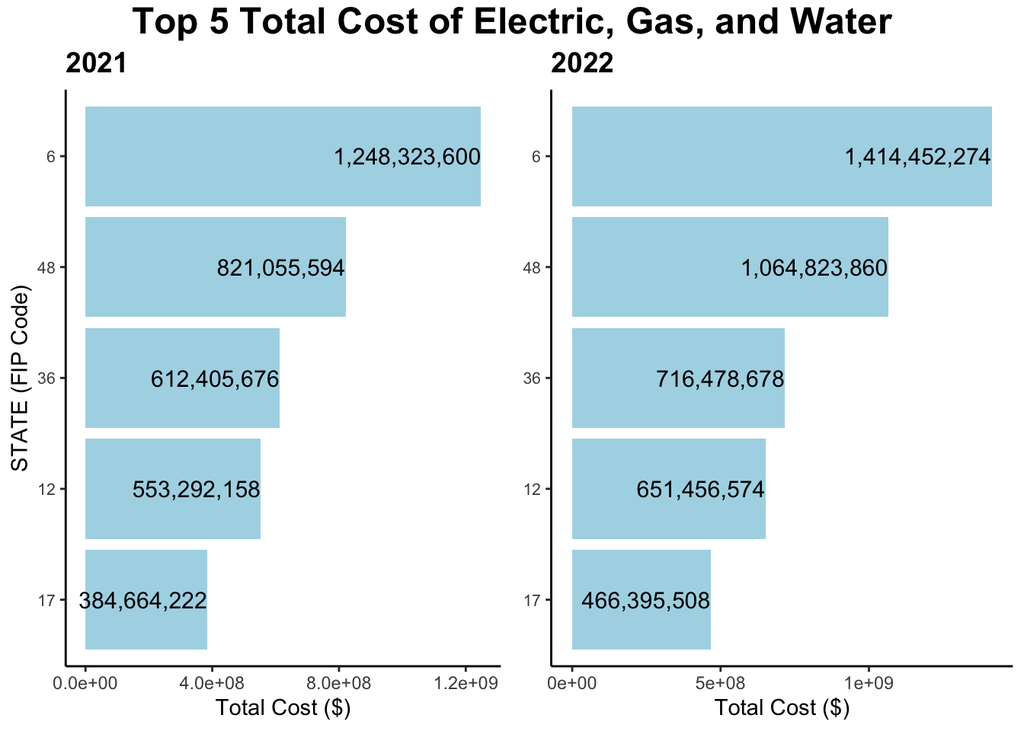

```r
q4_totalcost21_bar <- q4_totalcost_t5 %>%
                        ggplot() +
                          geom_col(aes(y = fct_reorder(STATEFIP, TotalCost21), x = TotalCost21), fill = "lightblue") +
                          geom_text(aes(x = TotalCost21, y = STATEFIP, label = scales::comma(TotalCost21)), hjust = 1, size = 4) +
                          labs(title = "2021") +
                          ylab(label = "STATE (FIP Code)") +
                          xlab(label = "Total Cost ($)") +
                          theme_classic() +
                          theme(axis.text.y = element_text(size = 8),
                                plot.title = element_text(size = 14, face = "bold"))

q4_totalcost22_bar <- q4_totalcost_t5 %>%
                        ggplot() +
                          geom_col(aes(y = fct_reorder(STATEFIP, TotalCost22), x = TotalCost22), fill = "lightblue") +
                          geom_text(aes(x = TotalCost22, y = STATEFIP, label = scales::comma(TotalCost22)), hjust = 1, size = 4) +
                          labs(title = "2022") +
                          ylab(label = NULL) +
                          xlab(label = "Total Cost ($)") +
                          theme_classic() +
                          theme(axis.text.y = element_text(size = 8),
                                plot.title = element_text(size = 14, face = "bold"))

q4_totalcost_bar <- ggarrange(q4_totalcost21_bar, q4_totalcost22_bar, ncol = 2, nrow = 1)
q4_totalcost_bar <- annotate_figure(q4_totalcost_bar, top = text_grob("Top 5 Total Cost of Electric, Gas, and Water", size = 18, face = "bold"))
q4_totalcost_bar
```

## 5.5 Question_5; Which state has the oldest, on average, residents?

Answer_Q5; The State of Maine (FIP Code = 23) on average has the oldest residents with the age of 46.8 years old in 2021 and 47.2 years old in 2022. The average age of USA residents grows from 42.7 years old in 2021 to 42.9 years old in 2022.

```r
q5_age2021 <- maindf %>%
                select(STATEFIP, YEAR, AGE) %>%
                filter(YEAR == 2021) %>%
                group_by(STATEFIP) %>%
                summarise(avgAge21 = round(mean(AGE), digits = 1))

q5_age2022 <- maindf %>%
                select(STATEFIP, YEAR, AGE) %>%
                filter(YEAR == 2022) %>%
                group_by(STATEFIP) %>%
                summarise(avgAge22 = round(mean(AGE), digits = 1))

q5_age2021_max <- slice_max(q5_age2021, avgAge21, n = 1)
q5_age2022_max <- slice_max(q5_age2022, avgAge22, n =1)

q5_age <- merge(q5_age2021_max, q5_age2022_max, all = TRUE)
q5_age
```

```
##   STATEFIP avgAge21 avgAge22
## 1       23     46.8     47.2
```

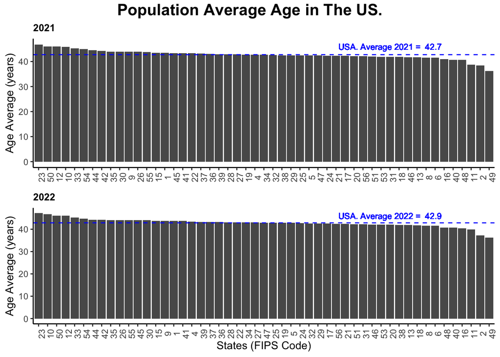

```r
q5_age21_hist <- q5_age2021 %>%
                   ggplot() +
                     geom_col(aes(x = fct_rev(fct_reorder(STATEFIP, avgAge21)), y = avgAge21)) +
                     geom_hline(aes(yintercept = mean(avgAge21)), color = "blue", linetype = "dashed") +
                     geom_text(aes(y = 46, x = 40, label = paste("USA. Average 2021 = ", round(mean(avgAge21),digits = 1))),
                               color = "blue",
                               size = 3,
                               face = "bold") +
                     labs(title = "2021") +
                     ylab(label = "Age Average (years)") +
                     xlab(label = NULL) +
                     theme_classic() +
                     theme(plot.title = element_text(face = "bold", size = 10),
                           axis.text.x = element_text(angle = 90))

q5_age22_hist <- q5_age2022 %>%
                   ggplot() +
                     geom_col(aes(x = fct_rev(fct_reorder(STATEFIP, avgAge22)), y = avgAge22)) +
                     geom_hline(aes(yintercept = mean(avgAge22)), color = "blue", linetype = "dashed") +
                     geom_text(aes(y = 46, x = 40, label = paste("USA. Average 2022 = ", round(mean(avgAge22),digits = 1))),
                               color = "blue",
                               size = 3,
                               face = "bold") +
                     labs(title = "2022") +
                     ylab(label = "Age Average (years)") +
                     xlab(label = "States (FIPS Code)") +
                     theme_classic() +
                     theme(plot.title = element_text(face = "bold", size = 10),
                           axis.text.x = element_text(angle = 90))

qq_age_hist <- ggarrange(q5_age21_hist, q5_age22_hist,
                         ncol = 1, nrow = 2)
qq_age_hist <- annotate_figure(qq_age_hist,
                               top = text_grob("Population Average Age in The US.",
                                                color = "black",
                                                face = "bold",
                                                size = 16))
qq_age_hist
```